# 疫情下居民消费和进出口研究

## 4 结论与展望

## 4.1 模型比较

利用季节ARIMA模型与灰色马尔科夫预测模型分别对2019年7月-12月的社会消费品零售总额、进出口总额的预测，计算两个模型的预测误差进行比较，比较结果如下：

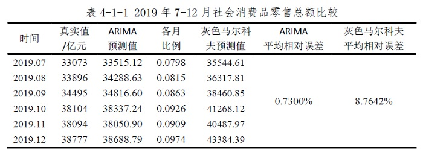

从表4-1-1中可以看出，季节ARIMA模型预测的平均相对误差为0.7300%，灰色马尔科夫预测模型的相对误差为8.7642%，比较相对误差可以发现，季节ARIMA模型的预测效果更好，后续将选择季节ARIMA模型对2020年1-3月的数据进行预测。

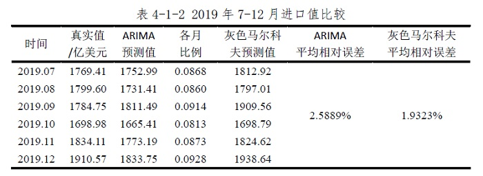

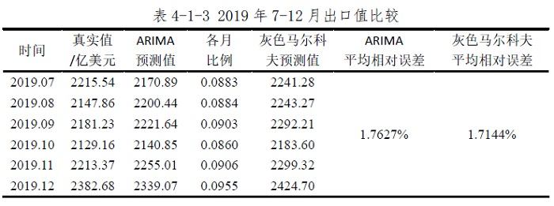

从表4-1-3中可以看出，季节ARIMA模型预测的平均相对误差为1.7627%，灰色马尔科夫预测模型的相对误差为1.7144%，比较发现，两个模型的相对误差大小相差不大，灰色马尔科夫预测模型的预测效果更好一些，所以选择灰色马尔科夫预测模型进行后续预测。

## 4.2 经济指标预测分析

根据上节比较结果，选择季节ARIMA模型对2020年1-3月的社会消费品零售总额进行预测，选择灰色马尔科夫预测模型对2020年1-3月的进出口总额进行预测，并且将国家统计局最新发布的1-3月实际经济指标与“如果不发生疫情”情景假设下经济模型所做的预测结果进行比较，测算了2020年1-3月疫情造成的“经济损失”，这是对疫情经济影响的一种估计。

(1)社会消费品零售总额

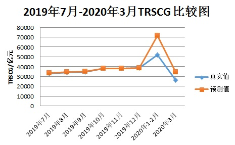

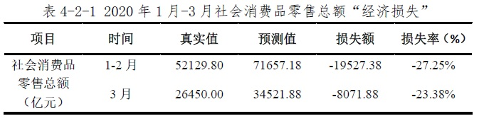

从表4-2-1中可以看出，对于社会消费品零售总额来说，1-2月累计的社会消费品零售额的“经济损失”约19527.38亿元，3月份“经济损失”8071.88亿元。

(2)进口总额

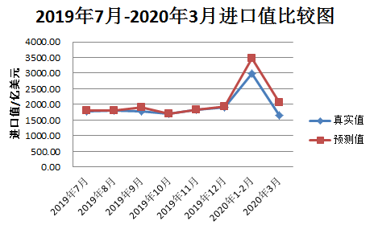

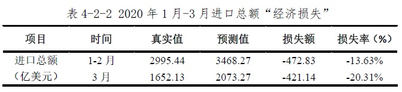

从表4-2-2中可以看出，对于进口总额来说，1-2月累计的进口总额“经济损失”为472.83和和3月进口额“经济损失”421.14亿美元。

(3)出口总额

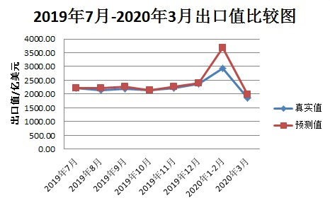

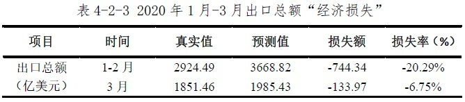

从表4-2-3中可以看出，对于出口总额来说，1-2月累计出口总额和3月份的出口“经济损失”分别为744.34亿美元、133.97亿美元。

## 4.3展望

(1) 聚类分析。接下来的研究将利用我国省级居民消费价格指数为研究对象进行聚类分析，并将聚类结果同各地区的疫情情况进行综合分析，研究疫情对物价的影响。

(2) 对研究结论提出相应建议措施。

[figure not shown]

谢谢大家！